# SPATIAL DATA VISUALIZATION

Sofía Galván and Miranta Kouvari

2023-08-25

1. First, let’s load and prepare the packages and data we are going to work with. In this case, we’ll use the `tetrapods` dataset provided by `palaeoverse` package.

```r
library(palaeoverse)
library(raster)
library(terra)
library(sf)
library(maps)
library(ggplot2)
library(RColorBrewer)
library(ggpubr)
library(rpaleoclim)
library(rgplates)


data(tetrapods)
tetrapods$mid_age <- (tetrapods$max_ma + tetrapods$min_ma)/2 #Roughly calculate medium ages.
```

### VECTOR DATA

2. For vector data, we’ll start working with `sp` package (although `sf` is preferred).

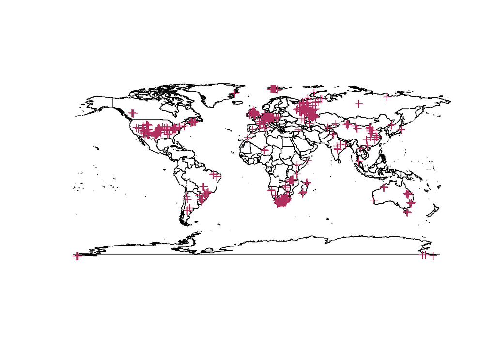

```r
tetrapods_sp <- tetrapods #We need to create a special R object for sp.
coordinates(tetrapods_sp) <- c("lng", "lat") #Now it's a SpatialPointDataframe
proj4string(tetrapods_sp) <- CRS("+proj=longlat +datum=WGS84 +no_defs")

World <- st_as_sf(map('world', plot = FALSE, fill = TRUE)) #from maps package, which returns a "sf" class object
World <- st_transform(World, crs = "+proj=longlat +datum=WGS84 +no_defs")
World_sp <- sf::as_Spatial(World) #Transform the sf object into a sp object

sp::plot(World_sp)
plot(tetrapods_sp, col = "maroon", add = T)
```

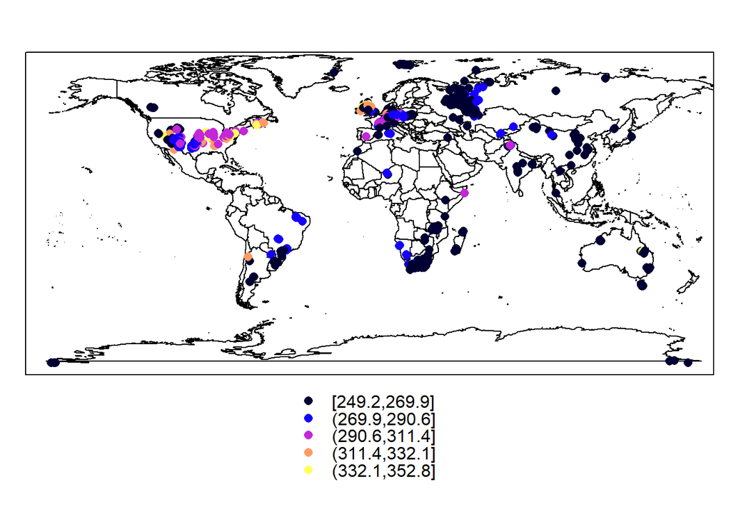

```r
spplot(tetrapods_sp, "mid_age",
       sp.layout = list(World_sp)) #Using a specific function to plot a variable with the data.
```

Now, we’ll calculate the number of occurrences per country and plot it:

```r
fos_percountry <- over(tetrapods_sp, World_sp)
table(fos_percountry$ID)[1:10] #Show first 10 results
```

```
##
##     Antarctica      Argentina      Australia         Brazil         Canada
##              5             20             57            104             49
##          Chile          China Czech Republic       Ethiopia         France
##              1             90             99              1             41
```

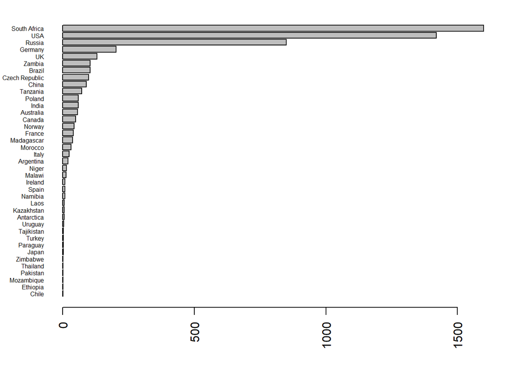

```r
par(mar = c(4, 4, 1, 2))
barplot(sort(table(fos_percountry$ID)),
        horiz = T, cex.names = 0.5,  las = 2)
```

```r
dev.off()
```

3. We repeat the previous steps with `sf` package.

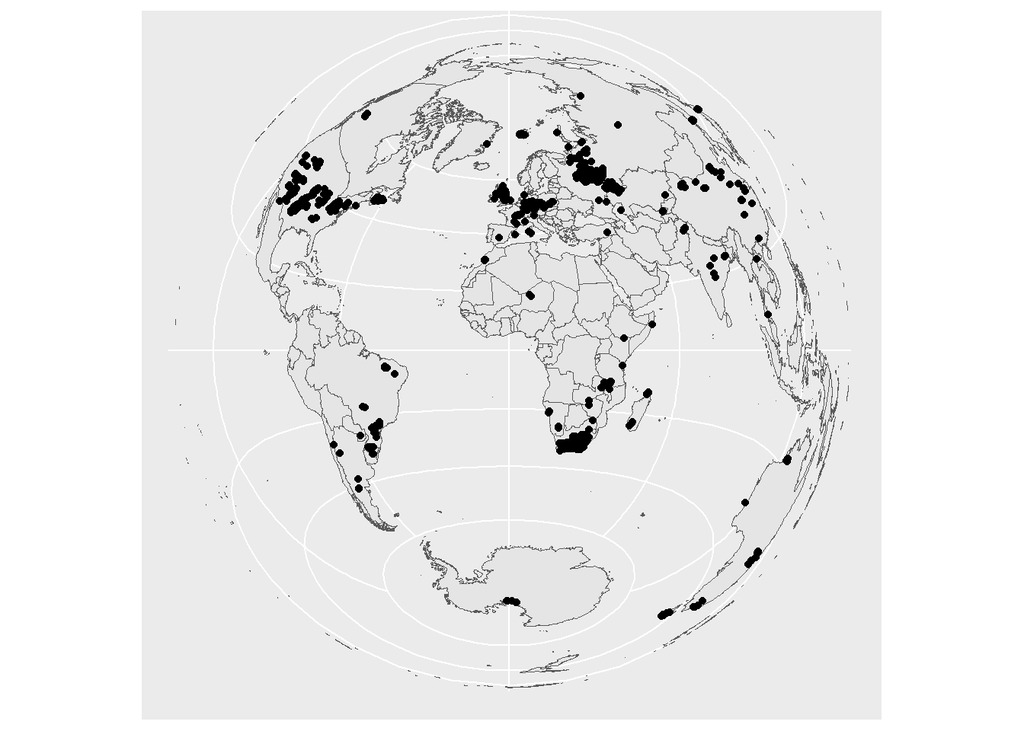

```r
tetrapods_sf <- st_as_sf(tetrapods, coords = c("lng", "lat"),
                         crs = "+proj=longlat +datum=WGS84 +no_defs") #Now, we need to create a sf object

#We can compare both object looking into str(tetrapods_sp) and str(tetrapods_sf)

World <- st_as_sf(map('world', plot = FALSE, fill = TRUE)) #from maps package, which returns a "sf" class object
World <- st_transform(World, crs = "+proj=longlat +datum=WGS84 +no_defs")

#there is specific ggplot functions for sf objects.
ggplot() +
  geom_sf(data = World) +
  geom_sf(data = tetrapods_sf) +
  coord_sf(crs = "+proj=laea") #in a equal area projection
```

Now, we’ll calculate the number of occurrences per country and plot it:

```r
sf::sf_use_s2(FALSE)
fos_percountry <- st_intersection(x = World, y = tetrapods_sf) #It takes a little of time
table(fos_percountry$ID)[1:10]
```

```
##
##     Antarctica      Argentina      Australia         Brazil         Canada
##              5             20             57            104             49
##          Chile          China Czech Republic       Ethiopia         France
##              1             90             99              1             41
```

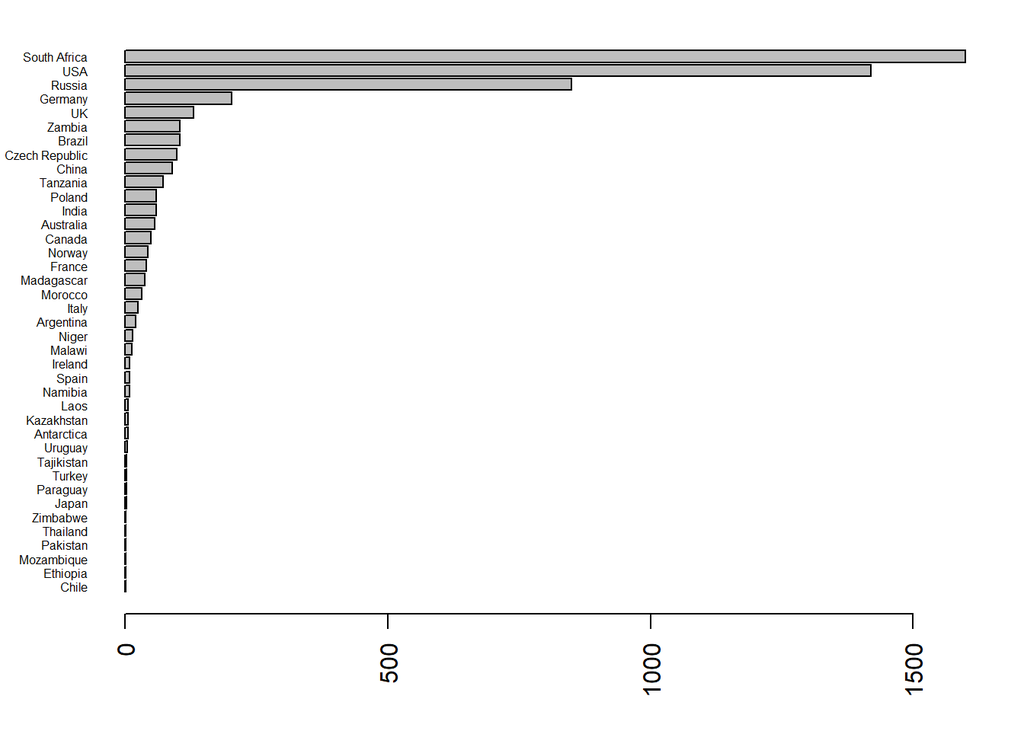

```r
par(mar = c(4, 4, 1, 2))
barplot(sort(table(fos_percountry$ID)),
        horiz = T, cex.names = 0.5,  las = 2)
```

```r
dev.off()
```

## RASTER DATA

4. We’ll use `terra` package and random environmental data from http://www.paleoclim.org/ using the `rpaleoclim` package (just as an example for visualization).

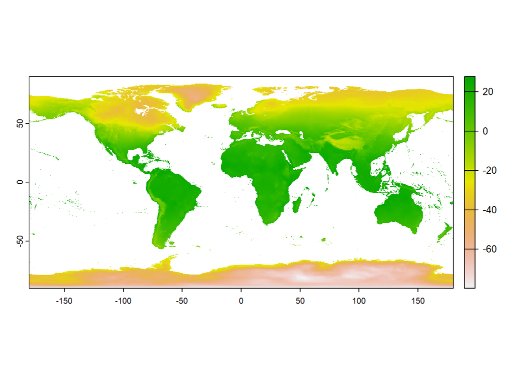

```r
Pclim_lgm <- paleoclim(period = "lgm", resolution = "10m")
Pclim_Temp <- Pclim_lgm$bio_1/10 # the original values are ºC*10
Pclim_Prec <- Pclim_lgm$bio_12 #mm/year
plot(Pclim_Temp)
```

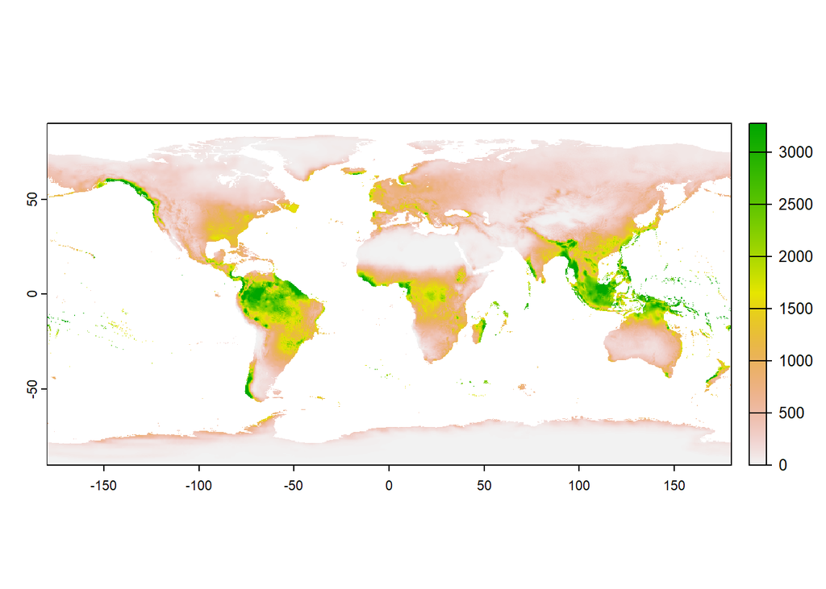

```r
plot(Pclim_Prec)
```

We need to transform these `SpatRaster` objects into a dataframe to plot them with `ggplot2`.

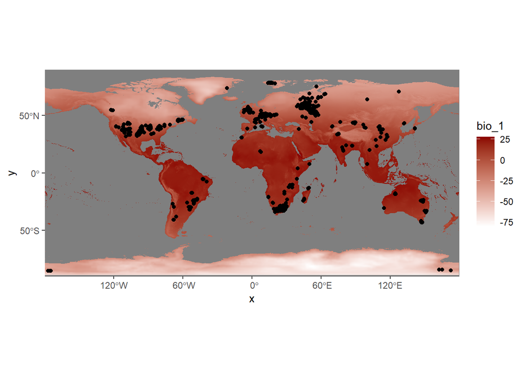

```r
Temp_df <- terra::as.data.frame(Pclim_Temp, xy = T, na.rm = F)

ggplot() +
  geom_raster(data = Temp_df, aes (x = x, y = y, fill = bio_1)) +
  scale_fill_gradient(low = "white", high = "darkred") +
  coord_sf(crs=crs(Pclim_Temp), expand = F) +
  geom_point(aes(x = tetrapods$lng, y = tetrapods$lat))
```

```r
#Let's create a color palette
my_gradient <- colorRampPalette(rev(brewer.pal(9, "RdYlBu")))

p1 = ggplot() +
  geom_raster(data = Temp_df, aes (x = x, y = y, fill = bio_1)) +
  xlab("") + ylab("") +
  scale_fill_gradientn(colors = my_gradient(30), name = "Temperature") +
  coord_sf(crs=crs(Pclim_Temp), expand = F) +
  geom_point(data = tetrapods, aes(x = lng, y = lat, color = as.factor(class))) +
  scale_color_manual(values = c("black", "royalblue3", "seagreen1"), name = "Class") +
  theme(legend.key.size = unit(0.35, "cm"))
```

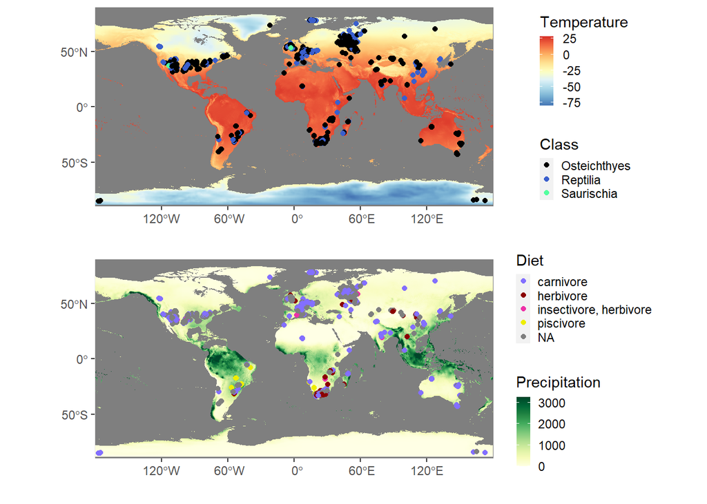

```r
Prec_df <- terra::as.data.frame(Pclim_Prec, xy = T, na.rm = F)
my_gradient2 <- colorRampPalette(brewer.pal(9, "YlGn"))

p2 = ggplot() +
  geom_raster(data = Prec_df, aes (x = x, y = y, fill = bio_12)) +
  xlab("") + ylab("") +
  scale_fill_gradientn(colors = my_gradient2(30), name = "Precipitation") +
  coord_sf(crs=crs(Pclim_Prec), expand = F) +
  geom_point(data = tetrapods, aes(x = lng, y = lat, color = as.factor(diet))) +
  scale_color_manual(values = c("slateblue1", "red4","maroon2","yellow2"), name = "Diet") +
  theme(legend.key.size = unit(0.35, "cm"))

ggarrange(p1, p2, ncol = 1, nrow = 2, align = "hv")
```

5. Imagine we want to plot fossil occurrences not just in the present, but deeper in time. To do so, we need to generate the palaeocoordinates for our occurrence data (`palaeorotate` function in `palaeoverse` package), as well as reconstruct the paleo-maps (`reconstruct` function in `rgplates` package)

```r
tetrapods_GOLONKA <- palaeorotate(tetrapods, age = "mid_age",
                                   method = "point", model = "GOLONKA")
midpoints <- sort(unique(tetrapods_GOLONKA$mid_age))
summary(midpoints)
```

```
##    Min. 1st Qu.  Median    Mean 3rd Qu.    Max.
##   249.2   266.1   285.7   289.0   309.2   352.8
```

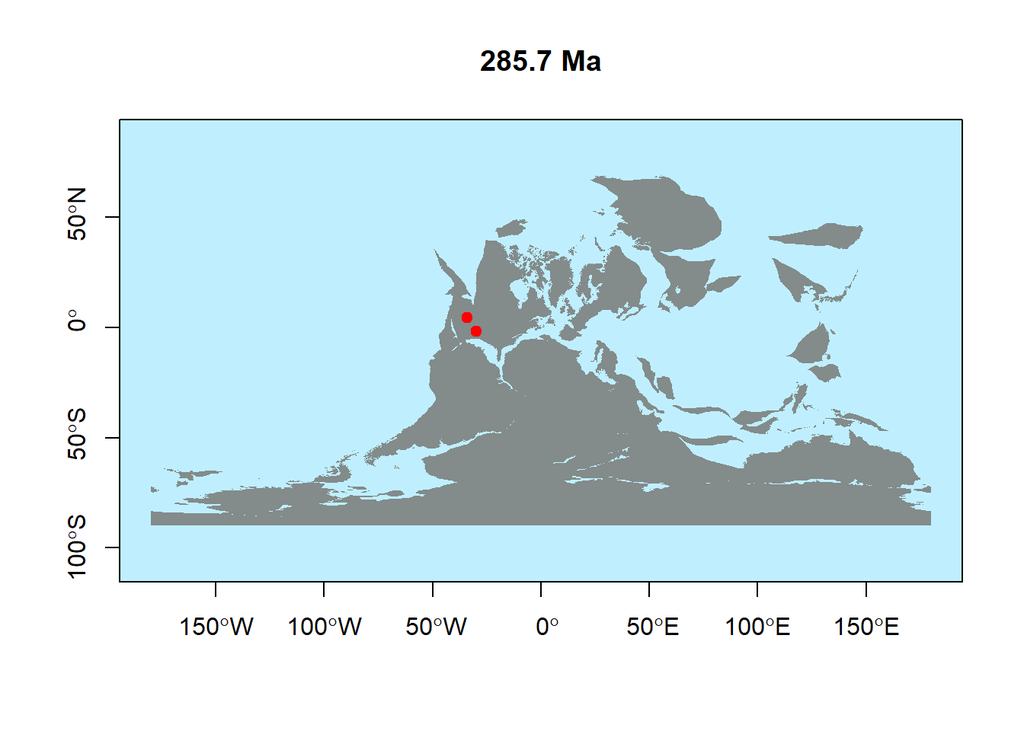

```r
#Let's plot, for example, the 285.7 Ma scenario
tetrapods_subset <- tetrapods_GOLONKA[tetrapods_GOLONKA$mid_age == 285.7,]
plates1 <- reconstruct("coastlines", age = 285.7, model = "GOLONKA") #reconstructing plates

plot(plates1, border=NA, col="azure4", axes = T, bgc = "lightblue1",
     main = paste("285.7", "Ma"))
points(tetrapods_subset$p_lng, tetrapods_subset$p_lat, col = "red", pch = 19)
```

6. Lastly, we should cite the packages we used, for example:

```r
citation("terra")
```

```
##
##   Hijmans R (2023). _terra: Spatial Data Analysis_. R package version
##   1.7-39, <https://CRAN.R-project.org/package=terra>.
##
## A BibTeX entry for LaTeX users is
##
##   @Manual{,
##     title = {terra: Spatial Data Analysis},
##     author = {Robert J. Hijmans},
##     year = {2023},
##     note = {R package version 1.7-39},
##     url = {https://CRAN.R-project.org/package=terra},
##   }
```

## EXTRA!

7. Let’s create a loop to plot fossil occurrences along time.

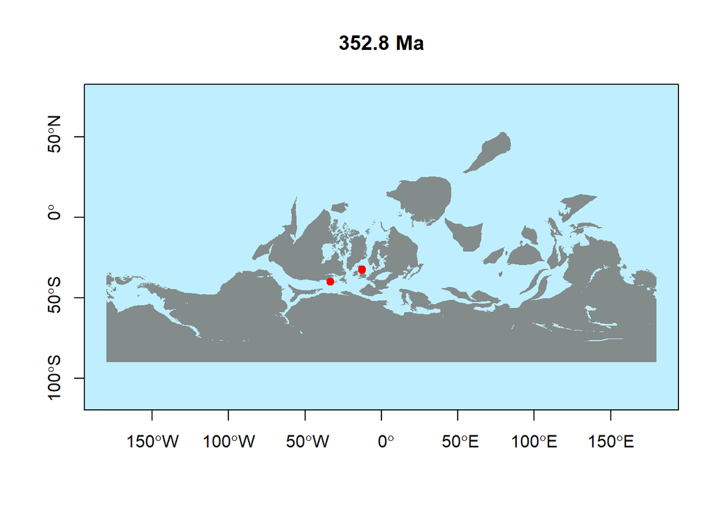

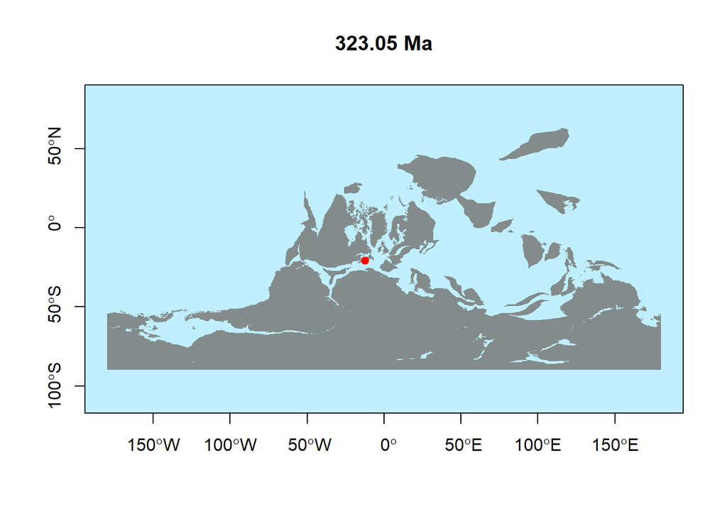

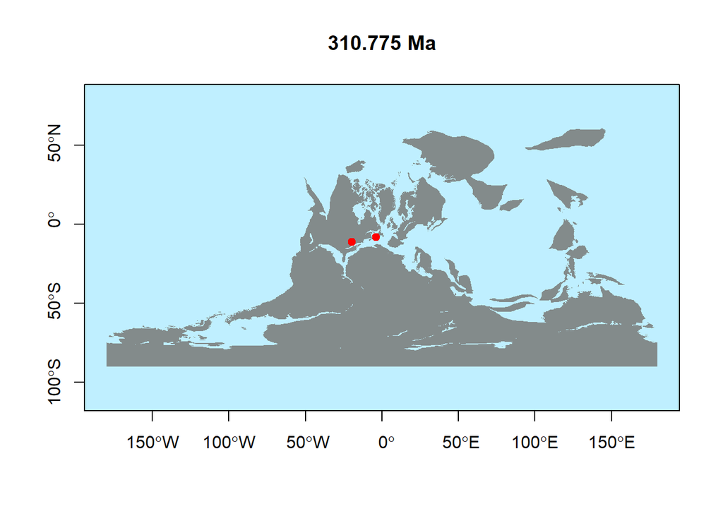

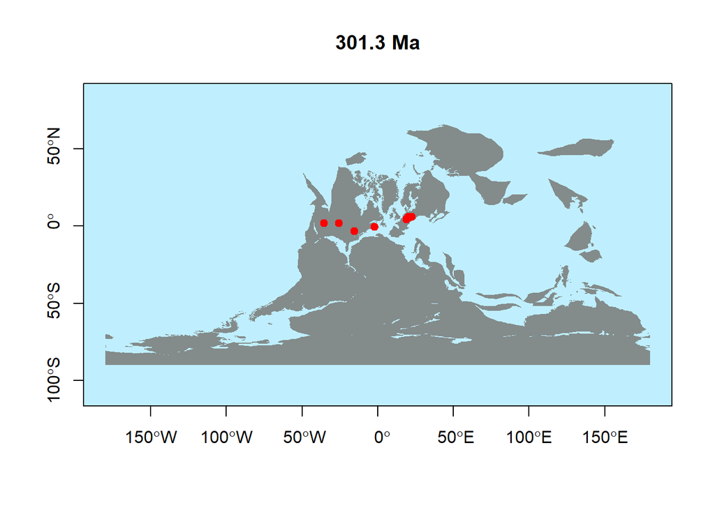

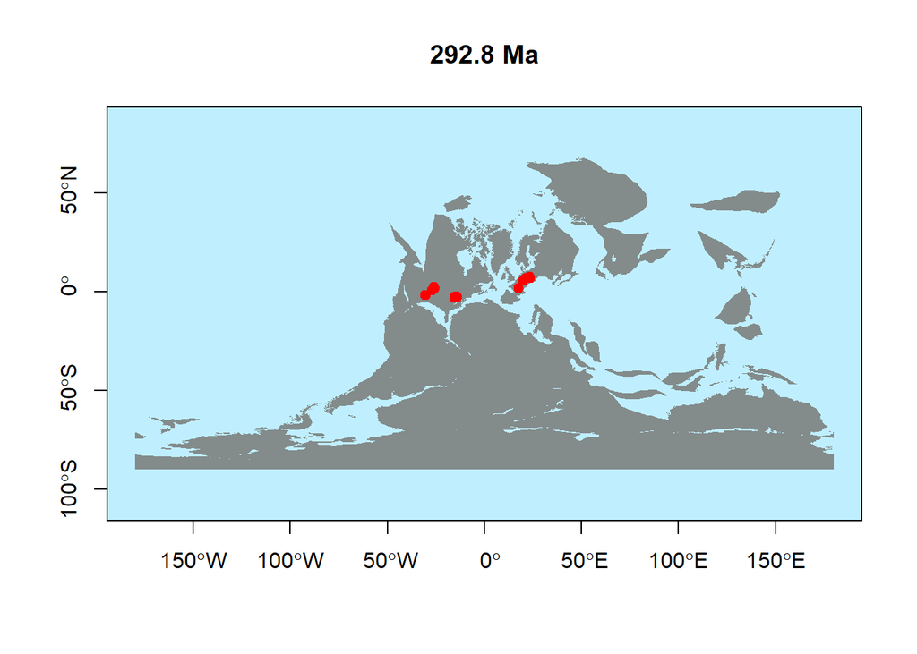

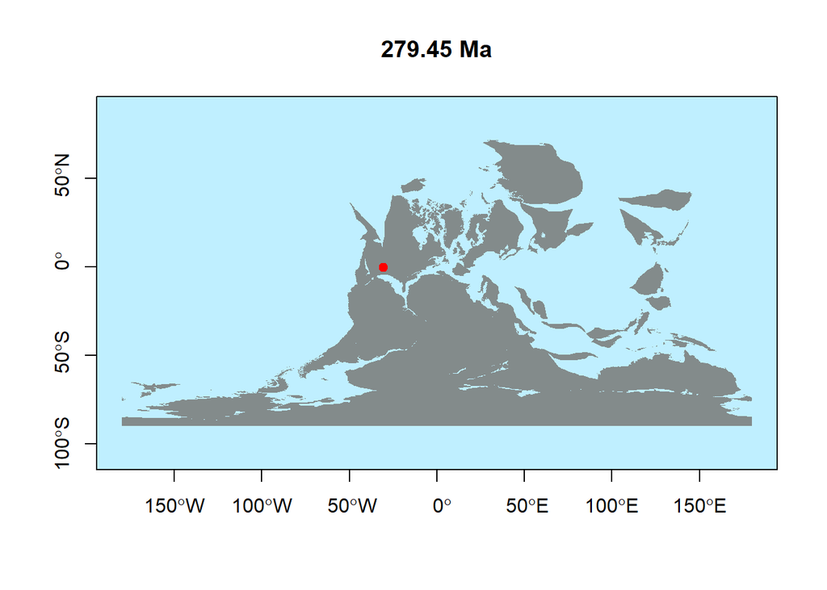

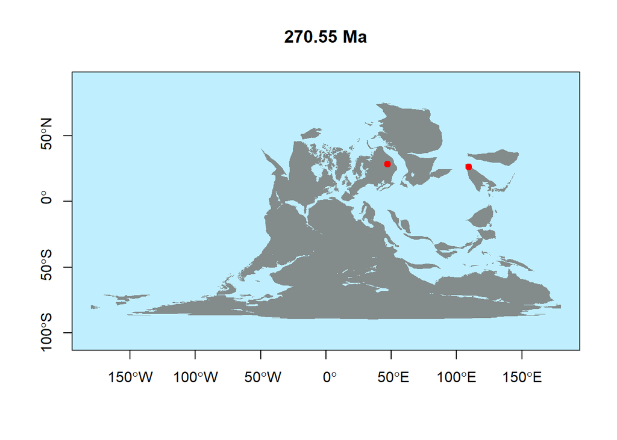

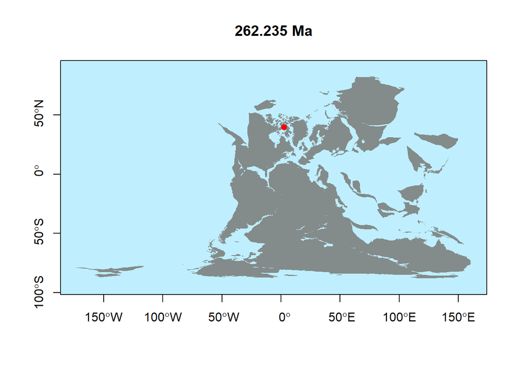

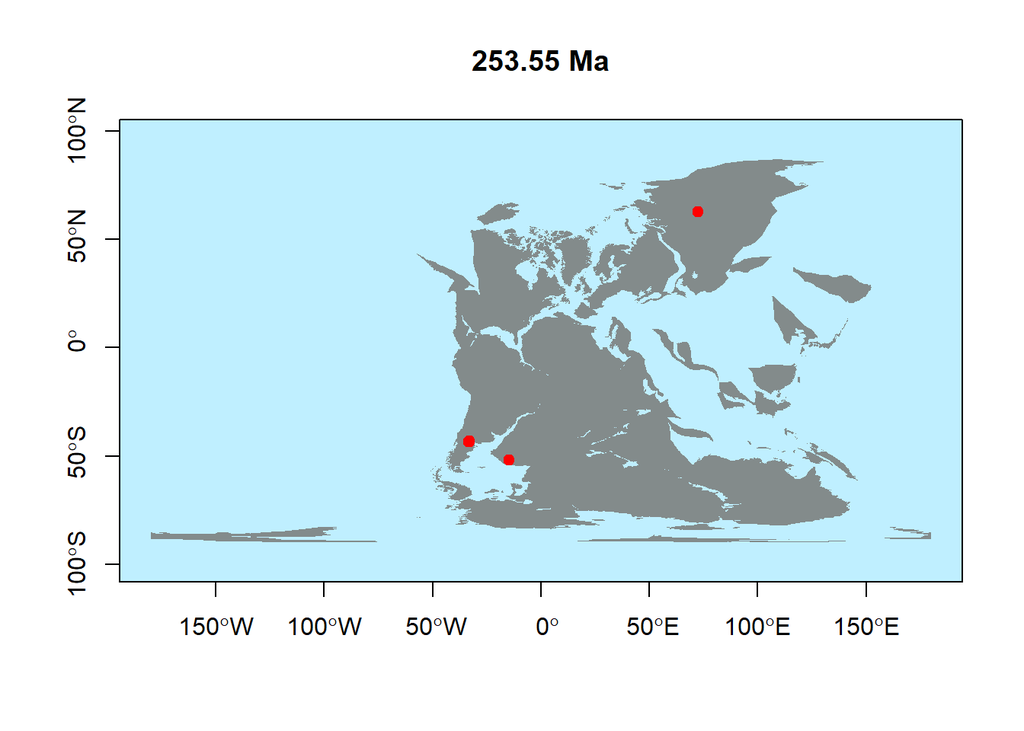

```r
my_midpoints <- seq(length(midpoints), 1, by = -10)

for (i in my_midpoints) {
  tetrapods_subset <- tetrapods_GOLONKA[tetrapods_GOLONKA$mid_age == midpoints[i],]
  plates <- reconstruct("coastlines", age = midpoints[i], model = "GOLONKA")
  plot(plates,border=NA, col="azure4", axes = T, bgc = "lightblue1",
       main = paste(midpoints[i], "Ma"))
  points(tetrapods_subset$p_lng, tetrapods_subset$p_lat, col = "red", pch = 19)
}
```

### References:

CRAN Task View: Analysis of Spatial Data. https://cran.r-project.org/web/views/Spatial.html

GPlates Web Service: https://gwsdoc.gplates.org/

PaleoClim: http://www.paleoclim.org/

R for Palaeobiologists: Workshop and Hackathon. https://hackathon.palaeoverse.org/